# Assignment

20077 Peiran Liu

2020/12/19

# 2020-9-22

## Question

Use knitr to produce 3 examples in the book.The 1st example should contain texts and at least one figure. The 2nd example should contain texts and at least one table. The 3rd example should contain at least a couple of LaTeX formulas.

## Answer

This is a test Rmd file with figures,tables and LaTeX formulas,which helps author familar with R Studio and English.As there is no requirement for content,examples are irrelevant with math and statistics.

### Example 1:Figure

When we want to insert pictures,there are two ways to complete.

(1)The drawing of the function in R Studio.There are two function images about trigonometric functions,which are drawing by R codes.

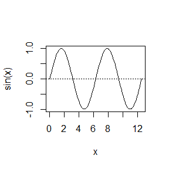

```r
curve(sin(x), 0, 4*pi)
abline(h=0, lty=3)
```

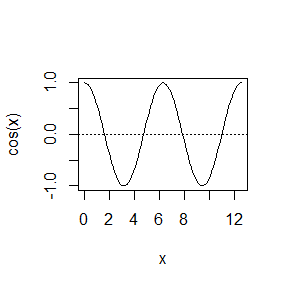

```r
curve(cos(x), 0, 4*pi)
abline(h=0, lty=3)
```

(2)Type the path and file name of the picture

```r
##The figure is hard to use in R packages,so eval=FALSE
knitr::include_graphics("smartphone/mi10u.png")
knitr::include_graphics("smartphone/P40.png")
knitr::include_graphics("smartphone/findX2Pro.png")
```

### Example 2:Table

When we want to write articles,it’s hard for us to output formula by Word,especially Greek letter.As a solution,LaTeX is a useful software.There is a table about a part of Greek letters with corresponding LaTeX codes.

| Greek letter | code |
| --- | --- |
| $\alpha$ | alpha |
| $\beta$ | beta |
| $\gamma$ | gamma |
| $\delta$ | delta |
| $\sigma$ | sigma |
| $\theta$ | theta |
| $\mu$ | mu |
| $\rho$ | rho |
| $\lambda$ | lambda |
| $\zeta$ | zeta |
| $\psi$ | psi |
| $\epsilon$ | epsilon |

In addition,when we have to output some Mathematical symbols,LaTeX is also a practical tool.

| Mathematical symbol | code |
| --- | --- |
| $\int_{min}^{max}$ | int_{min}^{max} |
| $\frac{a}{b}$ | frac{a}{b} |
| $\in$ | in |
| $\subset$ | subset |
| $\prod$ | prod |
| $\sum$ | sum |
| $\neq$ | neq |
| $\cap$ | cap |
| $\cup$ | cup |
| $\to$ | to |

### Example 3:LaTeX Formula

To make readers pay attention to form(Output LaTeX Formula) rather than contents,the author just show a simple math problem.

Get the limit of the mathematical expression
$$\lim_{x\to 0} \frac{e^x-1}{\sin x}$$

Solution.

(1)(L’Hospital’s rule)
$$\lim_{x\to 0} \frac{e^x-1}{\sin x}=\lim_{x\to 0} \frac{(e^x-1)'}{(\sin x)'}=\lim_{x\to 0} \frac{e^x}{\cos x}=1$$

(2)(substitution of equivalence infinitesimal)

According to basic knowledge of calculus,when $x\to 0$
$$e^x\to x,\sin x\to x$$
As a result
$$\lim_{x\to 0} \frac{e^x-1}{\sin x}=1$$

# 2020 9-29

### Caption

When generate the random sample,the results of each time are different.So sometimes the the empirical and theoretical distributions are different,so the density density histogram(empirical distribution) may not coincide with density curve(theoretical distribution).

### Question1(3.3)

The Pareto$(a, b)$ distribution has cdf
$$F(x)=1-\left(\frac{b}{x}\right)^a,x>=b>0,a>0.$$
Derive the probability inverse transformation $F^{-1}(U)$ and use the inverse transform method to simulate a random sample from the Pareto$(2, 2)$ distribution. Graph the density histogram of the sample with the Pareto$(2, 2)$ density superimposed for comparison.

### Answer1

$$u=1-(\frac{b}{x})^a\Rightarrow(\frac{b}{x})^a=1-u\Rightarrow\frac{b}{x}=(1-u)^\frac{1}{a}\Rightarrow x=\frac{b}{(1-u)^\frac{1}{a}}$$
the probability inverse transformation$F^{-1}(u)=\frac{b}{(1-u)^\frac{1}{a}}$

as $a=2,b=2$
$$x=F^{-1}(u)=\frac{2}{(1-u)^\frac{1}{2}}=\sqrt{\frac{4}{1-u}}$$
the pdf is
$$f(x)=F'(x)=\frac{8}{x^3}$$

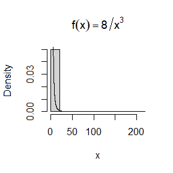

```r
n <- 1000
u <- runif(n)
x <- sqrt(4/(1-u)) #simulate a random sample from the Pareto(2, 2) distribution.
hist(x, prob = TRUE, main = expression(f(x)==8/x^{3}))#density histogram of sample
y <- seq(2, 25, .01)
lines(y, (2/y)^3) #density curve pdf
```

### Question2(3.9)

The rescaled Epanechnikov kernel is a symmetric density function.
$$f_e(x)=\frac{3}{4}(1-x^2), |x|\leq1$$
Devroye and Gyorfi give the following algorithm for simulation from this distribution. Generate i.i.d $U_1, U_2, U_3$∼ Uniform(−1, 1). If $|U_3|\geq|U_2|$ and $|U_3|\geq|U_1|$, deliver $U_2$; otherwise deliver $U_3$. Write a function to generate random variates from $f_e$, and construct the histogram density estimate of a large simulated random sample.

### Answer2

Using the acceptance-rejection method.

the pdf of random variable $Y$ is$f(y)=\frac 34(1-y^2)$,the random variable $X \sim U(-1,1)$,pdf is$g(x)=\frac 12$,so
$$\frac{f(x)}{g(x)}=\frac{3}{2}(1-x^2)\leq \frac 32$$
mark $c=\frac 32$.Random variable $U\sim U(0,1)$.When $u<\frac{f(x)}{cg(x)}$,accept $x$ and deliver $y=x$;else reject $x$.

```r
n <- 1000
k <- 0 #counter for accepted
j <- 0 #iterations,it's not necessary
y <- numeric(n)
while (k < n) {
u <- runif(1)
j <- j + 1
z <- runif(1)
x <- 2*z-1 #random variate from g(x)
if ( (1-x^2) >u ) {#when accept x
#we accept x
k <- k + 1
y[k] <- x
}
}
j#the number of variable X
```

```
## [1] 1528
```

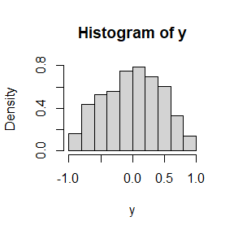

```r
hist(y, prob = TRUE)#the histogram of Y
```

### Question3(3.10)

Prove that the algorithm given in Exercise 3.9 generates variates from the density $f_e$.

### Answer3

As $U_1,U_2,U_3$i.i.d. ~$U(-1,1)$ mark random variable Y is
$$Y=U_2,\text{when} |U_3|\geq|U_2| \text{and} |U_3|\geq|U_1|,\\
Y=U_3,\text{others}$$
so the pdf of Y is
$$f_Y(x)=f(Y=U_2,U_2=x)+f(Y=U_3,U_3=x)$$
Calculate two functions
$$f(Y=U_2,U_2=x)=f(|U_3|\geq|U_2|,|U_3|\geq|U_1|,U_2=x)\\
=(\int_{-1}^{-|x|}+\int_{|x|}^{1})du_3(\int_{-|u_3|}^{|u_3|}\frac 18 du_1)\\
=(\int_{-1}^{-|x|}+\int_{|x|}^{1})\frac{|u_3|}{4}du_3\\
=\frac{1-x^2}{4}$$

$$f(Y=U_3,U_3=x)=f(U_3=x)-f(U_3=x,Y\not= U_3)\\
=f(U_3=x)-f(|U_3|\geq|U_2|,|U_3|\geq|U_1|,U_3=x)\\
=\int_{-1}^{1}d u_1\int_{-1}^{1} \frac{1}{8}d u_2-\int_{-|x|}^{|x|}d u_1\int_{-|x|}^{|x|} \frac{1}{8}d \\
=\frac{1-x^2}{2}$$
so the pdf of Y is
$$f_Y(x)=f(Y=U_2,U_2=x)+f(Y=U_3,U_3=x)=\frac 34(1-x^2)=f_e(x)$$
So the algorithm given in Exercise 3.9 generates variates from the density $f_e$.

### Question4(3.13)

It can be shown that the mixture in Exercise 3.12 has a Pareto distribution with cdf
$$F(y)=1-(\frac{\beta}{\beta+y})^{\gamma},y\geq0$$

(This is an alternative parameterization of the Pareto cdf given in Exercise 3.3.) Generate 1000 random observations from the mixture with $\gamma = 4$ and$\beta = 2$. Compare the empirical and theoretical (Pareto) distributions by graphing the density histogram of the sample and superimposing the Pareto density curve.

### Answer4

Assume $x=y+\beta\rightarrow y=x-\beta$,according to the question 1,probability inverse transformation of $x$ is$x=\frac{\beta}{(1-u)^\frac{1}{\gamma}}$,so probability inverse transformation of $y$ is
$$y=F^{-1}(u)=\frac{\beta}{(1-u)^\frac{1}{\gamma}}-\beta.$$
as $\gamma=4,\beta=2$.
$$y=\frac{2}{(1-u)^\frac{1}{4}}-2=(\frac{16}{1-u})^\frac {1}{4}-2.$$
the pdf is
$$f(y)=F'(y)=\frac{64}{(2+y)^5}$$

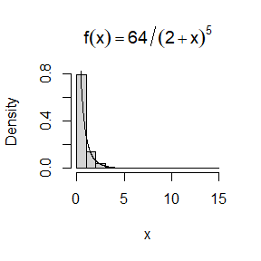

```r
n <- 1000
u <- runif(n)
x <- (16/(1-u))^(1/4)-2 #simulate a random sample from the Pareto(2, 2) distribution with 1000 observations
hist(x, prob = TRUE, main = expression(f(x)==64/(2+x)^5))#density histogram of sample(empirical distribution)
y <- seq(0, 4, .01)
lines(y, 2*(2/(y+2))^5)#density curve pdf(theoretical distribution)
```

The histogram and density plot suggests that the empirical and theoretical distributions approximately agree.

# 2020-10-13

### Question 1(5.1)

Compute a Monte Carlo estimate of
$$\int_{0}^{\frac{\pi}{3}}\sin t dt$$
and compare your estimate with the exact value of the integral.

### Answer

$$\int_{0}^{\frac{\pi}{3}}\sin t dt=-\cos t|_{t=0}^{t=\frac {\pi}{3}}=1-\frac 12=0.5$$
So the exact value of the integral is $0.5$.

```r
set.seed(79)
m <- 100000
x <- runif(m)##x~U(0,1)
t <- x*pi/3##t~U(0,pi/3)
theta.hat <- mean(sin(t))## the estimate
print(theta.hat)##output the estimate
```

```
## [1] 0.4784859
```

The estimate is 0.4784859,the exact value of the integral is $0.5$.

```r
print((theta.hat-0.5)/0.5)##the percent of bias
```

```
## [1] -0.04302824
```

### Question 2(5.6&&5.7)

(5.6) In Example 5.7 the control variate approach was illustrated for Monte Carlo integration of
$$\theta=\int_0^1 e^xdx$$
Now consider the antithetic variate approach. Compute $Cov (e^U , e^{1−U} )$ and $Var(e^U + e^{1−U} )$, where $U\sim Uniform(0,1)$. What is the percent reduction in variance of that can be achieved using antithetic variates (compared with simple MC)?

(5.7) Refer to Exercise 5.6. Use a Monte Carlo simulation to estimate θ by the antithetic variate approach and by the simple Monte Carlo method. Compute an empirical estimate of the percent reduction in variance using the antithetic variate. Compare the result with the theoretical value from Exercise 5.6.

### Answer

$$E(e^U+e^{1-U})=\int_0^1e^u+e^{1-u}du=(e^u-e^{1-u})|_{u=0}^{u=1}=2e-2$$
$$E(e^U)=\int_0^1e^udu=(e^u)|_{u=0}^{u=1}=e-1$$
$$E(e^U)=E(e^U+e^{1-U})-E(e^U)=e-1$$
Compute the Variance
$$Var(e^U+e^{1-U})=E[(e^U+e^{1-U})^2]-[E(e^U+e^{1-U})]^2\\
=\int_0^1(e^u+e^{1-u})^2du-(2e-2)^2\\
=(\frac{e^{2u}}{2}-\frac{e^{2-2u}}{2}+2eu)|_{u=0}^{u=1}-4e^2+8e-4\\
=-3e^2+10e-5$$
$$Var(e^U)=E[(e^U)^2]-[E(e^U)]^2\\
=\int_0^1(e^u)^2du-(e-1)^2\\
=(\frac{e^{2u}}{2})|_{u=0}^{u=1}-e^2+2e-1\\
=-\frac 12e^2+2e-\frac 32$$
$$Var(e^{1-U})=E[(e^{1-U})^2]-[E(e^{1-U})]^2\\
=\int_0^1(e^{1-u})^2du-(e-1)^2\\
=(-\frac{e^{2-2u}}{2})|_{u=0}^{u=1}-e^2+2e-1\\
=-\frac 12e^2+2e-\frac 32$$
Compute the covariance
$$Cov(e^U,e^{1-U})=\frac 12[Var(e^U+e^{1-U})-Var(e^U)-Var(e^{1-U})]\\
=-2e^2+6e-2$$

```r
print(-2*exp(2)+6*exp(1)-2)## the theoretical Covariance
```

```
## [1] -0.4684212
```

```r
print(-3*exp(2)+10*exp(1)-5)##the theoretical Variance
```

```
## [1] 0.01564999
```

for the Antithetic Variables$(e^U+e^{1-U})/2$,the variance is

```r
print((-3*exp(2)+10*exp(1)-5)/4)
```

```
## [1] 0.003912497
```

```r
set.seed(20077)
n <-10000
u <-runif(n)
MC.simple <-exp(u)##the smaple of Simple Monte Carlo
Mc.antithetic <-(exp(u)+exp(1-u))/2##the smaple of Antithetic Variables
theta.s <-mean(MC.simple)##the estimate of  Simple Monte Carlo
theta.a <-mean(Mc.antithetic)##the estimate of Antithetic Variables
sd.s <-sd(MC.simple)##the sd of Simple Monte Carlo
sd.a <-sd(Mc.antithetic)##the sd of Antithetic Variables
print(theta.s)##the estimate of  Simple Monte Carlo
```

```
## [1] 1.715201
```

```r
print(theta.a)##the estimate of  Simple Monte Carlo
```

```
## [1] 1.716926
```

```r
print(sd.s)##the sd of Simple Monte Carlo
```

```
## [1] 0.4874751
```

```r
print(sd.a)##the sd of Antithetic Variables
```

```
## [1] 0.0621996
```

```r
print((sd.s-sd.a)/sd.s)##the percent reduction in variance using the antithetic
```

```
## [1] 0.8724046
```

The theoretical value is$\theta=\int_0^1 e^x dx=e-1$

```r
print(exp(1)-1)##the theoretical value
```

```
## [1] 1.718282
```

### Question 3(5.11)

If $\theta_1$ and $\theta_2$ are unbiased estimators of $\theta$, and $\hat{\theta}_1$ and $\hat{\theta}_1$ are antithetic, we derived that $c^*=\frac 12$ is the optimal constant that minimizes the variance of $\hat{\theta}_c = c\hat{\theta}_1 + (1 − c)\hat{\theta}_2$. Derive $c^*$ for the general case. That is, if $\hat{\theta}_1$ and $\hat{\theta}_2$ are any two unbiased estimators of θ, find the value $c^*$ that minimizes the variance of the estimator $\hat{\theta}_c = c\hat{\theta}_1 + (1 − c)\hat{\theta}_2$in equation (5.11). ($c^*$ will be a function of the variances and the covariance of the estimators.)

### Answer

The equation (5.11) is
$$Var(\hat{\theta}_c)=Var(\hat{\theta}_2)+c^2Var(\hat{\theta}_1-\hat{\theta}_2)+2cCov(\hat{\theta}_2,\hat{\theta}_1-\hat{\theta}_2)$$
For $\forall$ random variable $X$,$Var(X)\geq 0$.In general case,$Var(X)\not =0$,so $Var(X)>0$.So
$$Var(\hat{\theta}_c)=Var(\hat{\theta}_1-\hat{\theta}_2)[c+\frac{Cov(\hat{\theta}_2,\hat{\theta}_1-\hat{\theta}_2)}{Var(\hat{\theta}_1-\hat{\theta}_2)}]^2+Var(\hat{\theta}_2)-\frac{[Cov(\hat{\theta}_2,\hat{\theta}_1-\hat{\theta}_2)]^2}{Var(\hat{\theta}_1-\hat{\theta}_2)}$$
So when $c+\frac{Cov(\hat{\theta}_2,\hat{\theta}_1-\hat{\theta}_2)}{Var(\hat{\theta}_1-\hat{\theta}_2)}=0$,$Var(\hat{\theta}_c)$ can get the minimum value$Var(\hat{\theta}_2)-\frac{[Cov(\hat{\theta}_2,\hat{\theta}_1-\hat{\theta}_2)]^2}{Var(\hat{\theta}_1-\hat{\theta}_2)}$.So
$$c^*=-\frac{Cov(\hat{\theta}_2,\hat{\theta}_1-\hat{\theta}_2)}{Var(\hat{\theta}_1-\hat{\theta}_2)}=\frac{Var(\hat{\theta}_2,\hat{\theta}_2)-Cov(\hat{\theta}_2,\hat{\theta}_1)}{Var(\hat{\theta}_1)+Var(\hat{\theta}_2)-2Cov(\hat{\theta}_2,\hat{\theta}_1)}$$

# 2020-10-20

### Question 1

Find two importance functions $f_1$ and $f_2$ that are supported on $(1,\infty)$ and are ‘close’ to
$$g(x)=\frac{x^2}{\sqrt{2\pi}}e^{-\frac{x^2}{2}},x>1$$
Which of your two importance functions should produce the smaller variance in estimating
$$\int_{1}^{\infty}\frac{x^2}{\sqrt{2\pi}}e^{-\frac{x^2}{2}}dx$$
by importance sampling? Explain

### Answer

$$f_1(x)=I(x>1)\frac{xe^{-\frac{x^2}{2}}}{e^{-\frac 12}}=I(x>1)e^{\frac 12}xe^{-\frac{x^2}{2}}$$
So
$$\int_{1}^{\infty} f_1(x)dx=-e^{\frac 12}e^{-\frac{x^2}{2}}|_{x=1}^{x=\infty}=1$$

$$f_2(x)=I(x>1)\frac{e}{5}x^2e^{-x}$$
And
$$\int_{1}^{\infty}f_2(x)dx=\int_{1}^{\infty}\frac{e}{5}x^2e^{-x}dx
=1$$

$$\frac{g(x)}{f_1(x)}=\frac{x}{\sqrt{2e\pi}},\frac{g(x)}{f_2(x)}=\frac{5}{\sqrt{2\pi}e}e^{x-\frac{x^2}{2}}$$

```r
set.seed(20077)
n <- 10000
theta.hat <- se <- numeric(2)
gf_1 <- numeric(n)
gf_2 <- numeric(n)
gf1 <- function(z) {##function g/f1
z/sqrt(2*pi*exp(1))
}
gf2 <- function(z) {##function g/f2
5*exp(z-z^2/2)/sqrt(2*pi*exp(2))
}
y <- runif(n)##y~U(0,1)
x <- 1/y##x~U(1,\infty)
gf_1 <- gf1(x)
gf_2 <- gf2(x)
theta.hat[1] <- mean(gf_1)
theta.hat[2] <- mean(gf_2)
se[1] <- sd(gf_1)
se[2] <- sd(gf_2)
rbind(theta.hat, se)
```

```
##                [,1]      [,2]
## theta.hat  2.206505 0.6231456
## se        31.191573 0.4968159
```

the variance of $gf_2$ is smaller than $gf_1$,the $gf_2$ is better choice.

### Question 2

Obtain the stratified importance sampling estimate in Example 5.13 and compare it with the result of Example 5.10.

### Answer

In each interval $(\frac{k-1}{5},\frac{k}{5}),k=1,2,3,4,5$
$$h_k(x)=I(\frac{k-1}{5}<x<\frac{k}{5})\frac{e^{-x}}{e^{-\frac{k-1}{5}}-e^{-\frac{k}{5}}},k=1,2,3,4,5$$
So the integral
$$\int_{\frac{k-1}{5}}^{\frac{k}{5}}h_k(x)dx=\frac{1}{e^{-\frac{k-1}{5}}-e^{-\frac{k}{5}}}\int_{\frac{k-1}{5}}^{\frac{k}{5}}e^{-x}dx=1$$
$$\frac{g(x)}{h_k(x)}=\frac{e^{-\frac{k-1}{5}}-e^{-\frac{k}{5}}}{1+x^2}$$

```r
set.seed(20077)
M <- 50000##number of replicates
theta.hat <- var.hat<- numeric(5)
h <- function(x,k){(exp(-(k-1)/5)-exp(-(k)/5))/(1+x^2)}##importance function on each subinterval
for(i in 1:5){
  x <- runif(M/5, (i-1)/5, i/5)
  y <- h(x,i)
  theta.hat[i]=mean(y)##the estimate on each subinterval
  var.hat[i]=var(y)##the variance on each subinterval
}
theta_hat=sum(theta.hat)
var_hat=sum(var.hat)
theta_hat##output the estimate
```

```
## [1] 0.5238734
```

```r
var_hat##output the variance
```

```
## [1] 6.245897e-05
```

```r
sqrt(var_hat)##the standard deviation
```

```
## [1] 0.007903099
```

### Question 3

Suppose that $X_1,...,X_n$ are a random sample from a from a lognormal distribution with unknown parameters. Construct a 95% confidence interval for the parameter $\mu$. Use a Monte Carlo method to obtain an empirical estimate of the confidence level.

### Answer

$X$：lognormal distribution,$\ln X\sim N(\mu,\sigma^2)$,the pdf is
$$f(x;\mu,\sigma)=I(x>0)\frac{1}{x\sqrt{2\pi}\sigma}e^{-\frac{(\ln x-\mu)^2}{2\sigma^2}}$$
As $\ln X\sim N(\mu,\sigma^2)$ and $\sigma^2$ is unkown,mark$Y=\ln X\sim N(\mu,\sigma^2)$.

According to the knowledge from mathematical statistics,mark $S_Y$
$$S_Y^2=\frac{1}{n-1}\sum_{i=1}^{n}(Y_i-\overline{Y})^2$$
So the variable $T$
$$T=\frac{\sqrt{n}(\overline{Y}-\mu)}{S_Y}\sim t_{n-1}$$
$$P(|T|\leq c)=P(-c\leq \frac{\sqrt{n}(\overline{Y}-\mu)}{S_Y}\leq c)=1-\alpha$$
If $c=t_{n-1}(\frac{\alpha}{2})$,the $1-\alpha$ confidence interval for the parameter $\mu$ is
$$\left[\overline{Y}-\frac{S_Y}{\sqrt{n}}t_{n-1}(\frac{\alpha}{2}),\overline{Y}+\frac{S_Y}{\sqrt{n}}t_{n-1}(\frac{\alpha}{2}) \right]$$
And$P(t_{n-1}>t_{n-1}(\alpha))=\alpha$

When $\alpha=0.05$,the 95% confidence interval is
$$\left[\overline{Y}-\frac{S_Y}{\sqrt{n}}t_{n-1}(0.025),\overline{Y}+\frac{S_Y}{\sqrt{n}}t_{n-1}(0.025) \right]$$

```r
set.seed(20077)
n <- 25##Sample size of each experiments
m <- 10000##Number of experiments
alpha <- 0.05
Y <- matrix(c(0:0) ,nrow=m , ncol=n)
t <- qt(1-(alpha/2),n-1)##t(alpha/2),use qt function
te <- c(1:m)## te=1 if mu in confidence region,else te=0
for (i in 1:m) {
  Y[i,] <- rnorm(n , mean=0 , sd=1)##normal distribution
  mu <- mean(Y[i,])
  se <- sqrt(var(Y[i,]))
  min_Y <- mu-se*t/sqrt(n)##lower limit of confidence region
  max_Y <- mu+se*t/sqrt(n)##upper limit of confidence region
  if(0<min_Y) {te[i]=0}
  else if(0>max_Y) {te[i]=0}
  else {te[i]=1}## te=1 if mu in confidence region,else te=0
}
conlevel <- mean(te)##empirical estimate of the confidence level
print(conlevel)##print empirical estimate of the confidence level
```

```
## [1] 0.9447
```

```r
cat("[",min_Y,",",max_Y,"]") ##One of the confidence levels
```

```
## [ -0.0966212 , 0.6970358 ]
```

The empirical estimate of the confidence level is 0.9447,here is a 95% confidence interval for the parameter $\mu$.
$$[-0.0966212,0.6970358]$$

### Question 4

Suppose a 95% symmetric t-interval is applied to estimate a mean, but the sample data are non-normal. Then the probability that the confidence interval covers the mean is not necessarily equal to 0.95. Use a Monte Carlo experiment to estimate the coverage probability of the t-interval for random samples of $\chi^2(2)$ data with sample size $n = 20$. Compare your t-interval results with the simulation results in Example 6.4. (The t-interval should be more robust to departures from normality than the interval for variance.)

### Answer

```r
set.seed(20077)
n <- 20##Sample size of each experiments
m <- 10000##Number of experiments
alpha <- 0.05
Y <- matrix(c(0:0) ,nrow=m , ncol=n)
t <- qt(1-(alpha/2),n-1)##t(alpha/2),use qt function
te <- c(1:m)## te=1 if mu in confidence region,else te=0
for (i in 1:m) {
  Y[i,] <- rchisq(n , df=2)##chi-square distribution
  mu <- mean(Y[i,])
  se <- sqrt(var(Y[i,]))
  min_Y <- mu-se*t/sqrt(n)##lower limit of confidence region
  max_Y <- mu+se*t/sqrt(n)##upper limit of confidence region
  if(2<min_Y) {te[i]=0}
  else if(2>max_Y) {te[i]=0}
  else {te[i]=1}## te=1 if mu in confidence region,else te=0
}
conlevel <- mean(te)##t-interval results
print(conlevel)##print t-interval results
```

```
## [1] 0.9173
```

```r
set.seed(20077)
m <- 10000##Number of experiments
n <- 20##Sample size of each experiments
alpha <- .05
test <- numeric(m)
for(i in 1:m){
  x <- rnorm(n, mean=0, sd=2)##normal distribution
  UCL <- (n-1) * var(x) / qchisq(alpha, df=n-1)## the upper confidence limit
  if(4<UCL) test[i]<-1
  else test[i]<-0## te=1 if mu in confidence region,else te=0
}
t<-mean(test)
t##simulation results in Example 6.4
```

```
## [1] 0.9456
```

Simulation results is 0.9456,t-interval results is 0.9173.The t-interval is more robust to departures from normality than the interval for variance.

# 2020-10-27

### Question 1(6.7)

Estimate the power of the skewness test of normality against symmetric Beta$(\alpha,\alpha)$ distributions and comment on the results. Are the results different for heavy-tailed symmetric alternatives such as $t(\nu)$?

### Answer

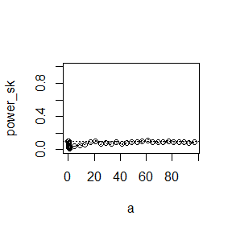

```r
set.seed(20077)
alpha <- 0.1
m <- 1000
n <- 20 ##Sample size
a <- c(seq(0.05,1,0.05),seq(1,97,4))##parameter of beta distribution
N <- length(a)
power_sk <- numeric(N)
power_t <- numeric(N)
cv <- qnorm(1-alpha/2, 0, sqrt(6*(n-2) / ((n+1)*(n+3))))
cv_t <- qt(1-alpha,n-1)

skew <- function(y){
  mean_y <- mean (y)
  m_2 <- mean((y-mean_y)^2)
  m_3 <- mean((y-mean_y)^3)
  return(sqrt(((m_3)^2)/((m_2)^3)))
}

ft <- function(z){
  m1<-mean(z)
  m2<-mean((z-m1)^2)
  return(sqrt(20/m2)*(m1-0.5))
}

for (j in 1:N) {
para <- a[j]
sktests <- numeric(m)
for (i in 1:m) {
x <- rbeta(n,para,para)
sktests[i] <- as.integer(abs(skew(x)) > cv)
}
power_sk[j] <- mean(sktests)

}

plot(a, power_sk, type = "b",
xlab = bquote(a), ylim = c(0,1))
abline(h = .1, lty = 3)
se_sk <- sqrt(power_sk * (1-power_sk) / m)
lines(a, power_sk+se_sk, lty = 3)
lines(a, power_sk-se_sk, lty = 3)
```

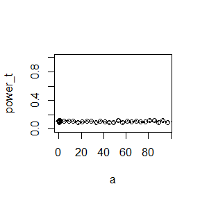

```r
for (j in 1:N) {
para <- a[j]
t_test <- numeric(m)
for (i in 1:m) {
x <- rbeta(n,para,para)
t_test[i] <- as.integer( ft(x) > cv_t)
}
power_t[j] <- mean(t_test)
}

plot(a, power_t, type = "b",
xlab = bquote(a), ylim = c(0,1))
abline(h = .1, lty = 3)
se_t <- sqrt(power_t * (1-power_t) / m)
lines(a, power_t+se_t, lty = 3)
lines(a, power_t-se_t, lty = 3)
```

Comment:the power don’t change a lot with the change of parameter.

The result is a little similar to the result in t test.

### Question 1(6.8)

Refer to Example 6.16. Repeat the simulation, but also compute the F test of equal variance, at significance level $\hat{\alpha}=$ 0.055. Compare the power of the Count Five test and F test for small, medium, and large sample sizes. (Recall that the F test is not applicable for non-normal distributions.)

### Answer

```r
set.seed(20077)
m<- 10000
n <- c(20,100,500)
alpha <- 0.055

c5test <- function(x, y) {
X <- x - mean(x)
Y <- y - mean(y)
outx <- sum(X > max(Y)) + sum(X < min(Y))
outy <- sum(Y > max(X)) + sum(Y < min(X))
# return 1 (reject) or 0 (do not reject H0)
return(as.integer(max(c(outx, outy)) > 5))
}




Ftest <- function(x, y, i) {
V_x  <- var(x)
V_y  <- var(y)
k <- c(20,100,500)
qF <- c(qf(1-alpha,k[1],k[1]),qf(1-alpha,k[2],k[3]),qf(1-alpha,k[3],k[3]))
return(as.integer( V_x/V_y > qF[i]))
}


sigma1 <- 1
sigma2 <- 1.1
power_c5<-numeric(3)
power_F<-numeric(3)
pF<- pc5<- numeric(m)
for(i in 1:3){
  for(j in 1:m){
      x <- rnorm(n[i], 0, sigma1)
      y <- rnorm(n[i], 0, sigma2)
      pF[j] <- Ftest(x,y,i)
      pc5[j] <- c5test(x,y)
  }
  power_c5[i] <- mean(pc5)
  power_F[i]<- mean(pF)
}
print(power_c5)
```

```
## [1] 0.0677 0.1672 0.2883
```

```r
print(power_F)
```

```
## [1] 0.0240 0.0166 0.0000
```

### Question 1(6.c)

Repeat Examples 6.8 and 6.10 for Mardia’s multivariate skewness test. Mardia [187] proposed tests of multivariate normality based on multivariate generalizations of skewness and kurtosis. If $X$ and $Y$ are iid, the multivariate population skewness $\beta_{1,d}$ is defined by Mardia as
$$\beta_{1,d}=E[(X-\mu)^T\Sigma^{-1}(Y-\mu)]^3$$
Under normality, $\beta_{1,d}$ The multivariate skewness statistic is
$$b_{1,d}=\frac{1}{n^2}\sum_{i,j=1}^{n}[(X_i-\overline{X})^T\hat{\Sigma}^{-1}(X_j-\overline{X})]^3$$
where$\hat{\Sigma}$ is the maximum likelihood estimator of covariance. Large values of $b_{1,d}$ are significant. The asymptotic distribution of $nb_{1,d}/6$ is chisquared with $d(d + 1)(d + 2)/6$ degrees of freedom.

### Answer

The maximum likelihood estimator of covariance is
$$\hat{\Sigma}=\sum_{i=1}^n\frac {1}{n}(X_i-\overline{X})(X_i-\overline{X})^T$$
Assume the dimension $d$ is 2,and $X$ is standard multivariate normal distribution.

```r
set.seed(2007)
library("MASS")
alpha <- 0.05
m <- 1000
n <- 20
cv_1 <- qchisq(1-alpha/2,2)
cv_2 <- qchisq(alpha/2,2)
Sigma <- matrix(c(10,3,3,2),2,2)

sk <- function(x,n){
  l <- nrow(x)
  x1 <- x[,1]
  x2 <- x[,2]
  mean_X1 <- mean(x1)
  mean_X2 <- mean(x2)
  m_11 <- sum((x1-mean_X1)^2)
  m_12 <- sum((x1-mean_X1)*((x2-mean_X2)))
  m_21 <- sum((x1-mean_X1)*(x2-mean_X2))
  m_22 <- sum((x2-mean_X2)^2)
  M <- matrix(c(m_11,m_12,m_21,m_22),nrow=2,ncol=2)
  Mm<-solve(M)##Inverse matrix
  result <- 0
  for(i in 1:n){
    for(j in 1:n){
      a <- matrix(c(x1[i]-mean_X1,x2[i]-mean_X2),nrow=1,ncol=2)
       b <- matrix(c(x1[j]-mean_X1,x2[j]-mean_X2),nrow=2,ncol=1)
       result <- result+a%*%Mm%*%b
    }
  }
  return(result)
}

re<-numeric(m)
for(j in 1:m){
  x <- mvrnorm(n=20, rep(0, 2), Sigma)
  ske <- sk(x,n)
  if(ske>cv_1) {re[j]=1}
  else if(ske<cv_2) {re[j]=1}
  else {re[j]=0}
}
p <- mean(ske)
print(p)
```

```
## [1] 1.266348e-16
```

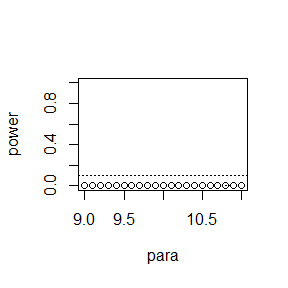

```r
para <- seq(9,11,0.1)##parameter change
lp <- length(para)
power <- numeric(lp)

for(i in 1:lp){
  for(j in 1:m){
  x <- mvrnorm(n=20, rep(0, 2), matrix(c(para[i],3,3,2),2,2))
  ske <- sk(x,n)
  if(ske>cv_1) {re[j]=1}
  else if(ske<cv_2) {re[j]=1}
  else {re[j]=0}
}
power[i] <- mean(ske)
}

##Curve
plot(para, power, type = "b",
xlab = bquote(para), ylim = c(0,1))
abline(h = .1, lty = 3)
se <- sqrt(power * (1-power) / m)
lines(para, power+se, lty = 3)
lines(para, power-se, lty = 3)
```

### Question 4

If we obtain the powers for two methods under a particular simulation setting with 10,000 experiments: say, 0.651 for one method and 0.676 for another method. Can we say the powers are different at 0.05 level?

(a)What is the corresponding hypothesis test problem?

(b)What test should we use? Z-test, two-sample t-test, paired-t test or McNemar test?

(c)What information is needed to test your hypothesis?

### Answer (a)

$$\text{$H_0$:the powers of two sample are different}\Longleftrightarrow\text{$H_1$:the powers of two sample are same}$$
the significance level is 0.05

### Answer (b)

As we can not that two samples are independant,it’s better to use McNemar test.

### Answer (c)

Only need to know the power 0.651 and 0.676.

# 2020-11-3

### Question1 (7.1)

Compute a jackknife estimate of the bias and the standard error of the correlation statistic in Example 7.2.

### Answer

```r
set.seed(20077)
library(bootstrap)##the data of law
n <- nrow(law)
cor_j <- numeric(n)
cor_hat <- cor(law$LSAT,law$GPA)

for(i in 1:n){##Jackknife Sample
  law_j <- law[-i,]
  cor_j[i] <-cor(law_j$LSAT,law_j$GPA)
}

cor_jack <- mean(cor_j)
bias_jack <- (n-1)*(cor_jack-cor_hat)
se_jack <-  sqrt((n-1)/n*sum((cor_j-cor_jack)^2))


result<-matrix(c(cor_jack,bias_jack,se_jack),nrow=1,ncol=3)
rownames(result) <- c('Jackknife')
colnames(result) <- c('estimate','bias', 'se')
result
```

```
##            estimate         bias        se
## Jackknife 0.7759121 -0.006473623 0.1425186
```

### Question2 (7.5)

Refer to Exercise 7.4. Compute 95% bootstrap confidence intervals for the mean time between failures $\frac{1}{\lambda}$ by the standard normal, basic, percentile, and BCa methods. Compare the intervals and explain why they may differ.

### Answer

Compute the Maximum Likelihood Estimate of $\lambda$
$$l(X;\lambda)=\ln L(X;\lambda)=\sum_{i=1}^n \ln f(x_i;\lambda)=n\ln\lambda-\sum_{i=1}^n \lambda x_i$$
$$\frac{\partial l}{\partial \lambda}=\frac{n}{\lambda}-\sum_{i=1}^nx_i$$
if $\frac{\partial l}{\partial \lambda}=0$,then
$$\hat{\lambda}_{MLE}=\frac{1}{\overline{X}}$$
So the estimate of $\frac{1}{\lambda}$ is
$$\hat{(\frac{1}{\lambda})}=\overline{X}$$

```r
set.seed(20077)
library(boot)##the data of aircondit
B <- 10000
alpha <- 0.05
len <- nrow(aircondit)
air <- numeric(len)
for(i in 1:len){
  air[i] <- aircondit[i,]
}
time_boot<-numeric(B)
time_hat<-mean(air)


for(i in 1:B){
  air_boot<- sample(air,len,replace=TRUE)
  time_boot[i] <- mean(air_boot)
}## the Bootstrap sample


boot.n <- function(th,th_hat,conf){## normal confidence interval
  se_hat <- sd(th)
  z <- qnorm(1-conf/2,mean=0,sd=1)
  result_norm<-matrix(c(th_hat-z*se_hat,th_hat+z*se_hat),nrow=1,ncol=2)
  colnames(result_norm) <- c('0.025','0.975')
  rownames(result_norm) <- c('norm')
  print(result_norm)
}

boot.p <- function(th,conf) {##percentile confidence interval
quantile(th,probs = c((1-conf)/2,(1+conf)/2))
}


boot.b <- function(th,th_hat,conf) {##basic confidence interval
  th_minus <- 2*th_hat-th
  quantile(th_minus,probs=c((1-conf)/2,(1+conf)/2))
}


boot.BCa <-##the BCa function from textbook
function(x, th0, th, stat, conf = .95) {
# bootstrap with BCa bootstrap confidence interval
# th0 is the observed statistic
# th is the vector of bootstrap replicates
# stat is the function to compute the statistic
x <- as.matrix(x)
n <- nrow(x)
N <- 1:n
alpha <- (1 + c(-conf, conf))/2
zalpha <- qnorm(alpha)
z0 <- qnorm(sum(th < th0) / length(th))
th.jack <- numeric(n)
for (i in 1:n) {
J <- N[1:(n-1)]
th.jack[i] <- stat(x[-i, ], J)
}
L <- mean(th.jack) - th.jack
a <- sum(L^3)/(6 * sum(L^2)^1.5)
adj.alpha <- pnorm(z0 + (z0+zalpha)/(1-a*(z0+zalpha)))
limits <- quantile(th, adj.alpha, type=6)
return(list("est"=th0, "BCa"=limits))
}

time.boot <- function(dat, index){
# input: dat, data; index, a vector of the bootstrap index
# output: theta, the estimated theta using the bootstrap sample
air.boot <- dat[index]
time.hat<-mean(air.boot)
return(time.hat)
}



boot.n(time_boot,time_hat,1-alpha)##normal confidence interval
```

```
##         0.025    0.975
## norm 105.7206 110.4461
```

```r
boot.p(time_boot,1-alpha)##percentile confidence interval
```

```
##      2.5%     97.5%
##  46.58333 191.66667
```

```r
boot.b(time_boot,time_hat,1-alpha)##basic confidence interval
```

```
##     2.5%    97.5%
##  24.5000 169.5833
```

```r
boot.BCa(air,th0 = time_hat,th = time_boot,stat = time.boot)##BCa confidence interval
```

```
## $est
## [1] 108.0833
##
## $BCa
##  6.60977% 99.56195%
##  56.41667 222.69839
```

As we can see,the length of normal confidence interval is smaller than the other three confidence intervals.In conclusion,the standard normal method is not a good choice.

These four methods have different purpose,they have different principle.As the methods are not same,the results are different.

### Question3 (7.8)

Refer to Exercise 7.7. Obtain the jackknife estimates of bias and standard error of $\hat{\theta}$.

### Answer

```r
set.seed(20077)
library(bootstrap) #for the score data
B<-1000
n<-nrow(scor)
m<-ncol(scor)
lambda_hat <- eigen(cov(scor))$values
theta_hat <- lambda_hat[1] / sum(lambda_hat)

theta_jack <- numeric(n)
for (i in 1:n) {
scor_jack <- scor [-i,]
lambda_jack <- eigen(cov(scor_jack))$values
theta_jack[i] <- lambda_jack[1] / sum(lambda_jack)
}
bias_hat_jack <- (n - 1) * (mean(theta_jack) - theta_hat)
se_hat_jack <-  sqrt((n-1)/n*sum((theta_jack-mean(theta_jack))^2))

result<-matrix(c(mean(theta_jack),bias_hat_jack,se_hat_jack),nrow=1,ncol=3)
rownames(result) <- c('Jackknife')
colnames(result) <- c('estimate','bias', 'se')
result
```

```
##            estimate        bias         se
## Jackknife 0.6191273 0.001069139 0.04955231
```

### Question4 (7.11)

In Example 7.18, leave-one-out (n-fold) cross validation was used to select the best fitting model. Use leave-two-out cross validation to compare the models.